# Semantic Segmentation: One Label per Pixel

A semantic segmentation model labels every pixel of an image with a class: *road*, *building*, *sky*. It does not separate two people standing side by side, because both pixels are just `person`. Models return this as one dense map of shape `(H, W)` holding a class id per pixel.

supervision turns that map into `sv.Detections`, with one detection per class id holding a mask, a tight box and a `class_name`. Every annotator, filter and sink then works as usual. Which method to call depends on where the map comes from:

- `sv.Detections.from_inference` for Roboflow Inference results, the same call as for detection models. It drops background id `0`, reads the per-pixel confidence map and can build compact masks.
- `sv.Detections.from_semantic_segmentation` for a raw map, such as the one an Ultralytics YOLO model returns, or to override the class names or keep the background. `from_inference` uses it for semantic results.
- `sv.Detections.from_transformers` for Hugging Face Transformers models. It keeps every class.

This cookbook runs four models, all trained on the 150-class ADE20K scene-parsing dataset, so their outputs are directly comparable:

- **RF-DETR**: the semantic segmentation models of the RF-DETR family, served by Roboflow Inference.
- **SegFormer**: a lightweight transformer encoder with a plain MLP decoder.
- **Mask2Former**: a mask-classification model that predicts a set of masks and classes.
- **YOLO26**: the semantic segmentation models of Ultralytics, a small convolutional network that predicts the class map in one pass.

## Install required packages

`inference` runs RF-DETR and brings `torch` along, `transformers` runs SegFormer and Mask2Former, and `ultralytics` runs YOLO26.

```python
%pip install -q inference transformers ultralytics
```

%pip install -q inference transformers ultralytics

Semantic segmentation support needs supervision `0.32.0` or newer. This is a separate step with `--no-deps` because `inference` currently pins `supervision<0.31`, so one `pip install` cannot resolve both.

```python
%pip install -q --no-deps "supervision>=0.32.0"
```

%pip install -q --no-deps "supervision>=0.32.0"

Later sections compare models and draw results, so everything is imported in one place.

```python
%matplotlib inline

import urllib.request

import matplotlib.pyplot as plt
import numpy as np
import torch
from inference import get_model
from PIL import Image
from transformers import (
    AutoImageProcessor,
    AutoModelForUniversalSegmentation,
    SegformerForSemanticSegmentation,
)
from ultralytics import YOLO

import supervision as sv

# Apply tight layout before the plotting helpers display figures.
plt.rcParams["figure.autolayout"] = True

print(sv.__version__)
```

%matplotlib inline import urllib.request import matplotlib.pyplot as plt import numpy as np import torch from inference import get_model from PIL import Image from transformers import ( AutoImageProcessor, AutoModelForUniversalSegmentation, SegformerForSemanticSegmentation, ) from ultralytics import YOLO import supervision as sv # Apply tight layout before the plotting helpers display figures. plt.rcParams["figure.autolayout"] = True print(sv.__version__)

```
Matplotlib is building the font cache; this may take a moment.
```

```
0.32.0.dev0
```

## Download the sample image

Semantic models are easiest to tell apart on a scene with many classes, so this photo has a stone house, a tiled roof, a wall, trees, grass and sky. It is a validation image from the ADE20K scene-parsing dataset, which is released for non-commercial research use.

```python
image_url = "https://huggingface.co/datasets/hf-internal-testing/fixtures_ade20k/resolve/main/ADE_val_00000001.jpg"
image_path = "ade20k-house.jpg"
urllib.request.urlretrieve(image_url, image_path)
```

image_url = "https://huggingface.co/datasets/hf-internal-testing/fixtures_ade20k/resolve/main/ADE_val_00000001.jpg" image_path = "ade20k-house.jpg" urllib.request.urlretrieve(image_url, image_path)

```
('ade20k-house.jpg', <http.client.HTTPMessage at 0x122eeb770>)
```

The models take a Pillow image, and supervision annotators take a BGR array, so the photo is kept in both forms.

```python
pil_image = Image.open(image_path).convert("RGB")
image = sv.pillow_to_cv2(pil_image)
height, width = image.shape[:2]
print(f"Image size: {width}x{height}")
```

pil_image = Image.open(image_path).convert("RGB") image = sv.pillow_to_cv2(pil_image) height, width = image.shape[:2] print(f"Image size: {width}x{height}")

```
Image size: 683x512
```

The next plot shows the unannotated photo, as a reference for judging the masks below.

```python
sv.plot_image(image, size=(12, 12))
```

sv.plot_image(image, size=(12, 12))

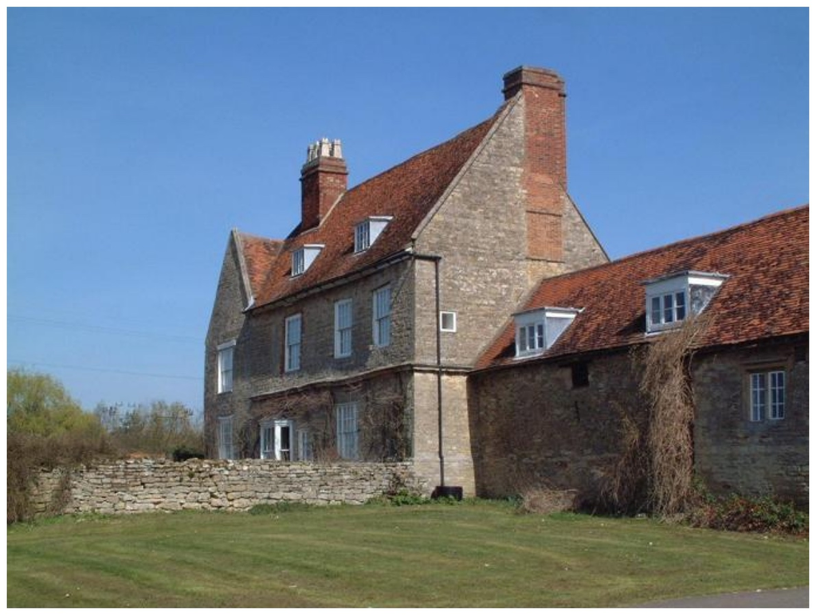

The sky and the building take up most of the frame, while the trees, the wall and the small plants on the right are the harder details.

## Shared setup

The Hugging Face models run on the device chosen here, while Inference and Ultralytics pick their own. Inference is much faster on a GPU, but the small checkpoints here also finish on a CPU.

```python
device = "cuda" if torch.cuda.is_available() else "cpu"
print(f"Running on {device}")
```

device = "cuda" if torch.cuda.is_available() else "cpu" print(f"Running on {device}")

```
Running on cpu
```

`LabelAnnotator` reads `class_name` from the detections on its own. The sky wraps around the house, so each label is placed at its class's centre of mass rather than at a corner of a frame-wide box.

Annotators pick a colour from the class id. A model that numbers the same classes differently can pass its own ids for the colour lookup, so that a class gets the same colour in every plot.

```python
mask_annotator = sv.MaskAnnotator(opacity=0.6)
label_annotator = sv.LabelAnnotator(
    text_position=sv.Position.CENTER_OF_MASS, text_scale=0.5, text_padding=4
)


def annotate(
    scene: np.ndarray, detections: sv.Detections, color_ids: np.ndarray | None = None
) -> np.ndarray:
    """Draw one coloured mask per class and write the class name on it."""
    annotated = mask_annotator.annotate(
        scene.copy(), detections, custom_color_lookup=color_ids
    )
    return label_annotator.annotate(annotated, detections, custom_color_lookup=color_ids)
```

mask_annotator = sv.MaskAnnotator(opacity=0.6) label_annotator = sv.LabelAnnotator( text_position=sv.Position.CENTER_OF_MASS, text_scale=0.5, text_padding=4 ) def annotate( scene: np.ndarray, detections: sv.Detections, color_ids: np.ndarray | None = None ) -> np.ndarray: """Draw one coloured mask per class and write the class name on it.""" annotated = mask_annotator.annotate( scene.copy(), detections, custom_color_lookup=color_ids ) return label_annotator.annotate(annotated, detections, custom_color_lookup=color_ids)

## RF-DETR with Roboflow Inference

RF-DETR semantic segmentation comes in six sizes, `rfdetr-sem-nano` to `rfdetr-sem-2xlarge`, pretrained on ADE20K. The smallest one downloads quickly and runs on a CPU.

```python
rfdetr = get_model("rfdetr-sem-nano")
```

rfdetr = get_model("rfdetr-sem-nano")

[output not shown]

`infer` returns one result per image. The result holds the map as a base64-encoded PNG, the class names and a per-pixel confidence map, so nothing needs unpacking by hand.

```python
rfdetr_result = rfdetr.infer(pil_image)[0]
```

rfdetr_result = rfdetr.infer(pil_image)[0]

```
Selected RF-DETR preprocessor implementation=base
```

`from_inference` is the same call as for detection and instance segmentation models. It recognises the semantic result and reads all three fields, giving one detection per class. Id `0` is background in this model, so it is left out.

```python
rfdetr_detections = sv.Detections.from_inference(rfdetr_result)
print(list(map(str, rfdetr_detections["class_name"])))
```

rfdetr_detections = sv.Detections.from_inference(rfdetr_result) print(list(map(str, rfdetr_detections["class_name"])))

```
['wall', 'sky', 'tree', 'road', 'grass', 'house']
```

The confidence map gives each detection the mean confidence of its pixels, which the other three models below do not report through supervision.

```python
for name, confidence in zip(rfdetr_detections["class_name"], rfdetr_detections.confidence):
    print(f"{str(name):<8} {confidence:.3f}")
```

for name, confidence in zip(rfdetr_detections["class_name"], rfdetr_detections.confidence): print(f"{str(name):<8} {confidence:.3f}")

```
wall     0.862
sky      0.987
tree     0.947
road     0.926
grass    0.975
house    0.963
```

Because id `0` is background, every ADE20K class sits one id higher here than in the Hugging Face checkpoints below. Shifting the ids back for the colour lookup gives each class the same colour as in the other models' plots.

```python
rfdetr_color_ids = rfdetr_detections.class_id - 1
```

rfdetr_color_ids = rfdetr_detections.class_id - 1

The next plot shows how the smallest RF-DETR divides the scene.

```python
sv.plot_image(annotate(image, rfdetr_detections, rfdetr_color_ids), size=(12, 12))
```

sv.plot_image(annotate(image, rfdetr_detections, rfdetr_color_ids), size=(12, 12))

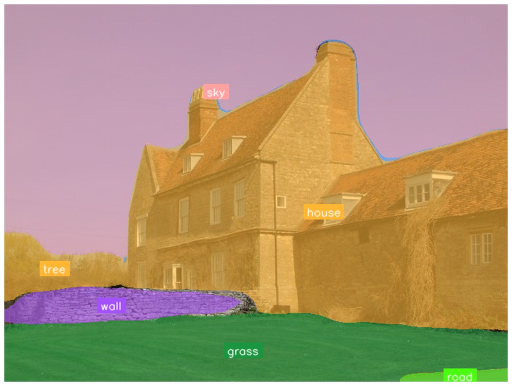

The outlines of the house, the wall and the lawn are tight even at this size. RF-DETR names the main structure `house` rather than `building`, and it reports no small `plant` regions. The thin unpainted line along the roof is background, id `0`, which was left out. The palette has 21 colours for 150 classes, so `house` shares its colour with `tree`.

Any semantic segmentation model deployed on Roboflow goes through the same call, with its own model id. `from_inference` hands the result to `sv.Detections.from_semantic_segmentation`, which can also be called directly to load a map alone, override the class names, or keep the background.

## SegFormer

SegFormer pairs a hierarchical transformer encoder with a small all-MLP decoder, which keeps it fast.

```python
segformer_name = "nvidia/segformer-b2-finetuned-ade-512-512"
segformer_processor = AutoImageProcessor.from_pretrained(segformer_name)
segformer = SegformerForSemanticSegmentation.from_pretrained(segformer_name).to(device)
```

segformer_name = "nvidia/segformer-b2-finetuned-ade-512-512" segformer_processor = AutoImageProcessor.from_pretrained(segformer_name) segformer = SegformerForSemanticSegmentation.from_pretrained(segformer_name).to(device)

Gradients are not needed for inference, so disabling them saves memory.

```python
inputs = segformer_processor(images=pil_image, return_tensors="pt").to(device)
with torch.no_grad():
    outputs = segformer(**inputs)
```

inputs = segformer_processor(images=pil_image, return_tensors="pt").to(device) with torch.no_grad(): outputs = segformer(**inputs)

The model predicts logits at a quarter of the input size. `post_process_semantic_segmentation` upsamples them to the image size and takes the most likely class per pixel, which gives the `(H, W)` map.

```python
segformer_map = segformer_processor.post_process_semantic_segmentation(
    outputs, target_sizes=[(height, width)]
)[0]
print(segformer_map.shape)
```

segformer_map = segformer_processor.post_process_semantic_segmentation( outputs, target_sizes=[(height, width)] )[0] print(segformer_map.shape)

```
torch.Size([512, 683])
```

`from_transformers` takes that tensor and the model's `id2label`. Nothing else is needed.

```python
segformer_detections = sv.Detections.from_transformers(
    segformer_map, id2label=segformer.config.id2label
)
print(list(map(str, segformer_detections["class_name"])))
```

segformer_detections = sv.Detections.from_transformers( segformer_map, id2label=segformer.config.id2label ) print(list(map(str, segformer_detections["class_name"])))

```
['wall', 'building', 'sky', 'tree', 'road', 'grass', 'plant']
```

The next plot shows whether the masks follow the outlines of the house, the wall and the lawn.

```python
sv.plot_image(annotate(image, segformer_detections), size=(12, 12))
```

sv.plot_image(annotate(image, segformer_detections), size=(12, 12))

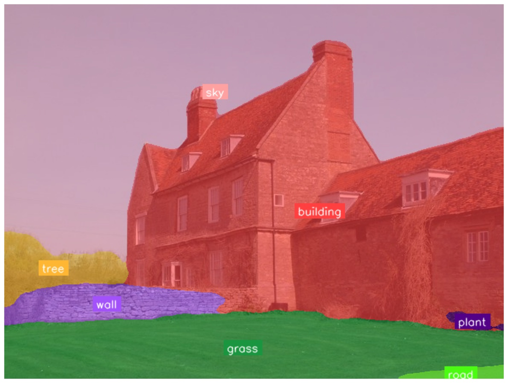

The large regions follow their outlines closely. The `sky` label lands on the chimney because the sky surrounds the house, so its centre of mass falls inside the building.

Each detection is an ordinary `sv.Detections` row, so the area of each mask directly gives the share of the image taken by each class.

```python
coverage = segformer_detections.area / (height * width)
for name, share in sorted(
    zip(segformer_detections["class_name"], coverage), key=lambda item: -item[1]
)[:5]:
    print(f"{str(name):<12} {share:6.1%}")
```

coverage = segformer_detections.area / (height * width) for name, share in sorted( zip(segformer_detections["class_name"], coverage), key=lambda item: -item[1] )[:5]: print(f"{str(name):<12} {share:6.1%}")

```
building      39.0%
sky           38.7%
grass         15.3%
wall           3.5%
tree           2.6%
```

## Mask2Former

Mask2Former predicts a fixed set of masks, each with a class score, and combines them into the semantic map. The checkpoint below is the semantic-segmentation variant.

```python
mask2former_name = "facebook/mask2former-swin-tiny-ade-semantic"
mask2former_processor = AutoImageProcessor.from_pretrained(mask2former_name)
mask2former = AutoModelForUniversalSegmentation.from_pretrained(mask2former_name).to(
    device
)
```

mask2former_name = "facebook/mask2former-swin-tiny-ade-semantic" mask2former_processor = AutoImageProcessor.from_pretrained(mask2former_name) mask2former = AutoModelForUniversalSegmentation.from_pretrained(mask2former_name).to( device )

[output not shown]

The inference call is the same as for SegFormer.

```python
inputs = mask2former_processor(images=pil_image, return_tensors="pt").to(device)
with torch.no_grad():
    outputs = mask2former(**inputs)
```

inputs = mask2former_processor(images=pil_image, return_tensors="pt").to(device) with torch.no_grad(): outputs = mask2former(**inputs)

Post-processing combines the predicted masks into the same `(H, W)` tensor, so the supervision call does not change.

```python
mask2former_map = mask2former_processor.post_process_semantic_segmentation(
    outputs, target_sizes=[(height, width)]
)[0]
mask2former_detections = sv.Detections.from_transformers(
    mask2former_map, id2label=mask2former.config.id2label
)
print(list(map(str, mask2former_detections["class_name"])))
```

mask2former_map = mask2former_processor.post_process_semantic_segmentation( outputs, target_sizes=[(height, width)] )[0] mask2former_detections = sv.Detections.from_transformers( mask2former_map, id2label=mask2former.config.id2label ) print(list(map(str, mask2former_detections["class_name"])))

```
['wall', 'building', 'sky', 'tree', 'road', 'grass', 'plant', 'path']
```

The next plot shows how Mask2Former treats the small regions at the bottom of the frame.

```python
sv.plot_image(annotate(image, mask2former_detections), size=(12, 12))
```

sv.plot_image(annotate(image, mask2former_detections), size=(12, 12))

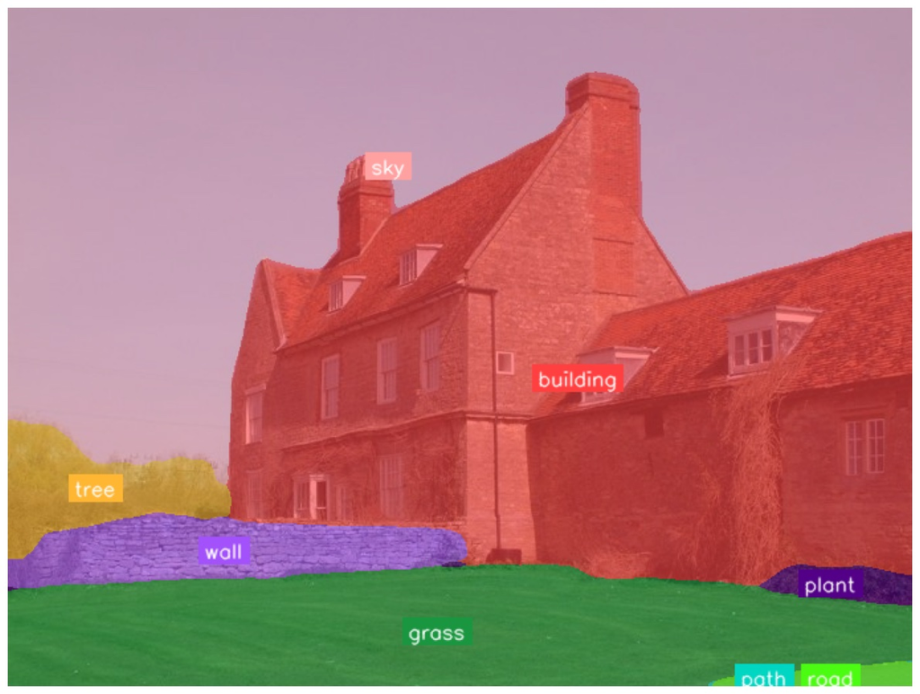

The large regions match SegFormer, and the paved corner at the bottom right is split into `road` and `path`.

## YOLO26

Ultralytics ships semantic segmentation models in its YOLO26 family. The `-sem-ade20k` checkpoints are pretrained on ADE20K in five sizes, from `yolo26n-sem-ade20k` to `yolo26x-sem-ade20k`. The medium one, `yolo26m-sem-ade20k`, is about 29 MB and also runs on a CPU. It needs no separate processor, because the model resizes the photo itself.

```python
yolo = YOLO("yolo26m-sem-ade20k.pt")
```

yolo = YOLO("yolo26m-sem-ade20k.pt")

Calling the model returns one result per image. `semantic_mask.data` holds the `(H, W)` class map at the size of the photo.

```python
yolo_result = yolo(pil_image, verbose=False)[0]
yolo_map = yolo_result.semantic_mask.data.cpu()
print(yolo_map.shape)
```

yolo_result = yolo(pil_image, verbose=False)[0] yolo_map = yolo_result.semantic_mask.data.cpu() print(yolo_map.shape)

```
torch.Size([512, 683])
```

The map goes through `from_semantic_segmentation`, with the names from `yolo.names`. This model has no background class, because ADE20K id `0` is `wall`, so `background_id=None` keeps every class.

```python
yolo_detections = sv.Detections.from_semantic_segmentation(
    yolo_map, class_map=yolo.names, background_id=None
)
print(list(map(str, yolo_detections["class_name"])))
```

yolo_detections = sv.Detections.from_semantic_segmentation( yolo_map, class_map=yolo.names, background_id=None ) print(list(map(str, yolo_detections["class_name"])))

```
['wall', 'building', 'sky', 'tree', 'road', 'grass', 'plant', 'house', 'path']
```

The next plot shows how the medium YOLO26 divides the scene.

```python
sv.plot_image(annotate(image, yolo_detections), size=(12, 12))
```

sv.plot_image(annotate(image, yolo_detections), size=(12, 12))

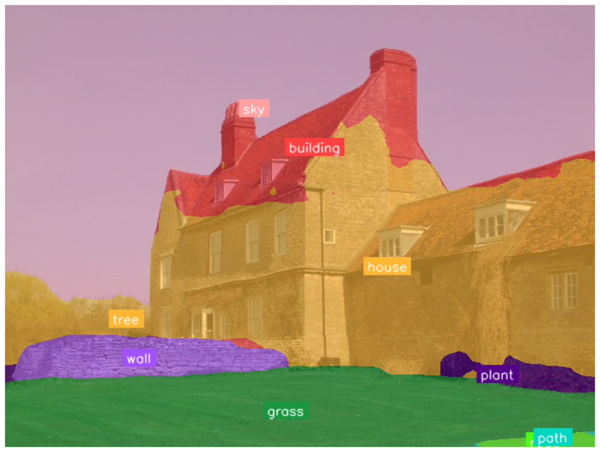

The sky, the wall, the lawn and the plants have tight outlines. The house is split between two classes: the roof is `building`, while the walls and part of the right-hand roof are `house`. As in the RF-DETR plot, `house` shares its colour with `tree`. YOLO26 returns no confidence, so `confidence` is `None`.

## Compare the models

The models share one output type, so a side-by-side view takes one list comprehension. The next plot answers where they visibly differ.

```python
results = {
    "RF-DETR-Nano": rfdetr_detections,
    "SegFormer-B2": segformer_detections,
    "Mask2Former-Swin-T": mask2former_detections,
    "YOLO26m": yolo_detections,
}

color_ids = {"RF-DETR-Nano": rfdetr_color_ids}

sv.plot_images_grid(
    images=[
        annotate(image, detections, color_ids.get(name))
        for name, detections in results.items()
    ],
    grid_size=(2, 2),
    titles=list(results),
    size=(12, 12),
)
```

results = { "RF-DETR-Nano": rfdetr_detections, "SegFormer-B2": segformer_detections, "Mask2Former-Swin-T": mask2former_detections, "YOLO26m": yolo_detections, } color_ids = {"RF-DETR-Nano": rfdetr_color_ids} sv.plot_images_grid( images=[ annotate(image, detections, color_ids.get(name)) for name, detections in results.items() ], grid_size=(2, 2), titles=list(results), size=(12, 12), )

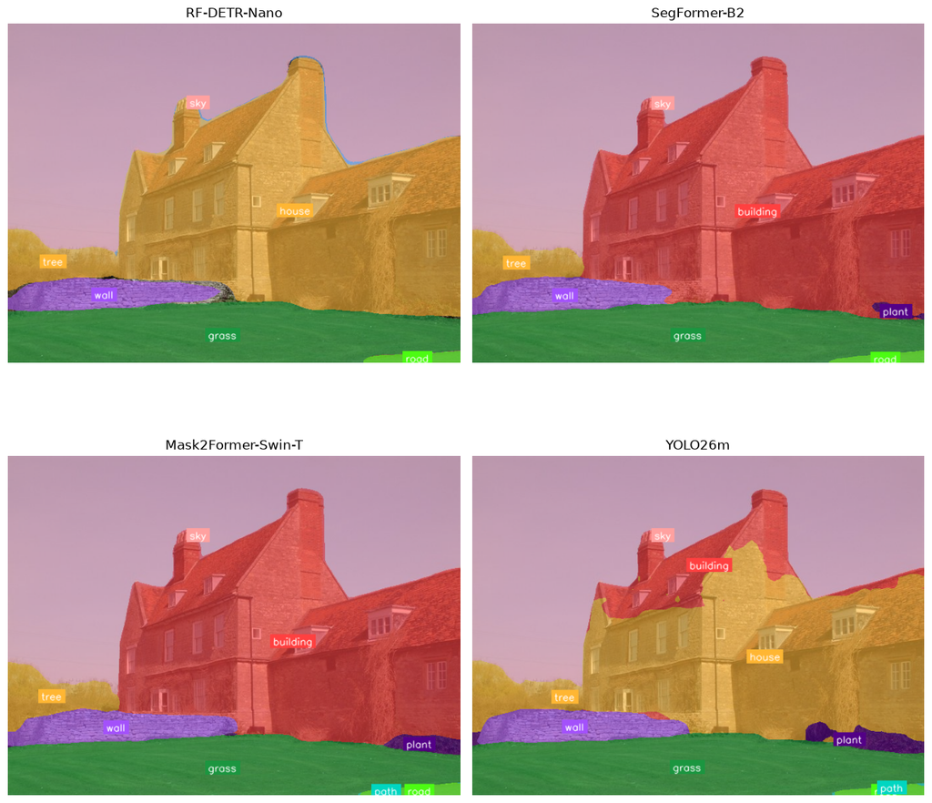

Each class now has the same colour in every panel. SegFormer and Mask2Former draw almost the same outlines. RF-DETR calls the whole house `house` instead of `building`, and YOLO26m splits it, keeping `building` for the roof. The corner at the bottom right is `path` in Mask2Former and YOLO26m, but not in the other two.

A model can spell a class name differently from another one, for example ADE20K's `conveyer belt` is `conveyor belt` in YOLO26, so comparing class ids avoids counting one class as two. RF-DETR reserves id `0` for background, which moves each ADE20K class up by one, so its ids are shifted back to line up with the others.

```python
class_ids = {name: set(d.class_id.tolist()) for name, d in results.items()}
class_ids["RF-DETR-Nano"] = set((rfdetr_detections.class_id - 1).tolist())
```

class_ids = {name: set(d.class_id.tolist()) for name, d in results.items()} class_ids["RF-DETR-Nano"] = set((rfdetr_detections.class_id - 1).tolist())

Classes reported by every model are the safe part of the scene, and classes reported by only one model show where to look closer.

```python
id2label = segformer.config.id2label
shared = set.intersection(*class_ids.values())
print(f"All four report: {sorted(id2label[i] for i in shared)}")
for name, ids in class_ids.items():
    others = set.union(*(other for n, other in class_ids.items() if n != name))
    print(f"Only {name}: {sorted(id2label[i] for i in ids - others)}")
```

id2label = segformer.config.id2label shared = set.intersection(*class_ids.values()) print(f"All four report: {sorted(id2label[i] for i in shared)}") for name, ids in class_ids.items(): others = set.union(*(other for n, other in class_ids.items() if n != name)) print(f"Only {name}: {sorted(id2label[i] for i in ids - others)}")

```
All four report: ['grass', 'road', 'sky', 'tree', 'wall']
Only RF-DETR-Nano: []
Only SegFormer-B2: []
Only Mask2Former-Swin-T: []
Only YOLO26m: []
```

Class lists hide how much area a disagreement covers, so the share of pixels with the same class id measures it directly. RF-DETR's map is rebuilt from its masks with the same shift. Its background pixels stay at `-1`, which counts them as disagreement.

```python
rfdetr_map = np.full((height, width), -1)
for class_id, mask in zip(rfdetr_detections.class_id, rfdetr_detections.mask):
    rfdetr_map[mask] = class_id - 1
```

rfdetr_map = np.full((height, width), -1) for class_id, mask in zip(rfdetr_detections.class_id, rfdetr_detections.mask): rfdetr_map[mask] = class_id - 1

Each pair of models is compared once.

```python
maps = {
    "RF-DETR-Nano": rfdetr_map,
    "SegFormer-B2": segformer_map.cpu().numpy(),
    "Mask2Former-Swin-T": mask2former_map.cpu().numpy(),
    "YOLO26m": yolo_map.numpy(),
}
names = list(maps)
for i, first in enumerate(names):
    for second in names[i + 1 :]:
        agreement = float((maps[first] == maps[second]).mean())
        print(f"{first} vs {second}: {agreement:.1%} of pixels agree")
```

maps = { "RF-DETR-Nano": rfdetr_map, "SegFormer-B2": segformer_map.cpu().numpy(), "Mask2Former-Swin-T": mask2former_map.cpu().numpy(), "YOLO26m": yolo_map.numpy(), } names = list(maps) for i, first in enumerate(names): for second in names[i + 1 :]: agreement = float((maps[first] == maps[second]).mean()) print(f"{first} vs {second}: {agreement:.1%} of pixels agree")

```
RF-DETR-Nano vs SegFormer-B2: 59.6% of pixels agree
RF-DETR-Nano vs Mask2Former-Swin-T: 59.5% of pixels agree
RF-DETR-Nano vs YOLO26m: 89.7% of pixels agree
SegFormer-B2 vs Mask2Former-Swin-T: 98.5% of pixels agree
SegFormer-B2 vs YOLO26m: 67.4% of pixels agree
Mask2Former-Swin-T vs YOLO26m: 67.7% of pixels agree
```

SegFormer and Mask2Former agree on 98.5% of pixels. RF-DETR and YOLO26m agree with each other on 89.7%, but only on about 60% and 67% with SegFormer and Mask2Former, and one naming difference explains most of it: SegFormer's `building` covers 39.0% of the image, RF-DETR calls that region `house`, and YOLO26m calls about 78% of it `house`.

## Large images: compact masks

A dense mask is one `(H, W)` boolean array per class, so a 4K image with 40 classes holds 40 full-size arrays. `from_semantic_segmentation` also accepts a raw map, and with `compact_masks=True` it stores each mask as a run-length encoded crop, built one class at a time. `background_id=None` keeps ADE20K's id `0`, which is the class `wall` rather than background.

```python
compact_detections = sv.Detections.from_semantic_segmentation(
    segformer_map,
    class_map=segformer.config.id2label,
    background_id=None,
    compact_masks=True,
)
print(type(compact_detections.mask).__name__)
```

compact_detections = sv.Detections.from_semantic_segmentation( segformer_map, class_map=segformer.config.id2label, background_id=None, compact_masks=True, ) print(type(compact_detections.mask).__name__)

```
CompactMask
```

Compact masks only change the storage, so they must decode to exactly the pixels of the dense masks.

```python
print(np.array_equal(np.asarray(compact_detections.mask), segformer_detections.mask))
```

print(np.array_equal(np.asarray(compact_detections.mask), segformer_detections.mask))

```
True
```

## What next

- Filter classes with the usual `sv.Detections` indexing, for example `detections[detections["class_name"] == "sky"]`.
- Try `sv.PolygonAnnotator` or `sv.HaloAnnotator` for other looks.
- Semantic segmentation cannot count objects, because it does not separate them. For that, use an instance segmentation model with `from_inference`, `from_ultralytics` or `from_transformers`.